# Data wrangling in Python - Data wrangling with NumPy - 2

One should look for what is and not what he thinks should be. (Albert Einstein)

# Module completion checklist

| Objective | Complete |
| --- | --- |
| Perform operations on NumPy arrays |  |
| Manipulating arrays using set operations |  |

# Helper functions: min and max

- Arrays have many useful functions available
- For instance you can check the minimum and maximum values of a numeric array

```python
import numpy as np

# Generate 5 numbers between 15 and 19.
x = np.linspace(15, 19, 5)

# Find the min of x.
np.amin(x)
```

```
15.0
```

```python
# Find the max of x.
np.amax(x)
```

```
19.0
```

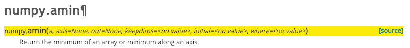

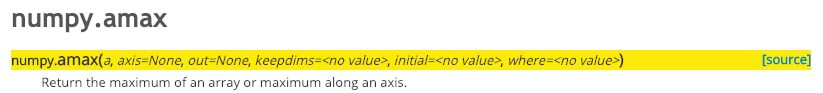

# Helper functions: argmin and argmax

- You can obtain the index of the maximum and minimum values in the array using the `argmax` and `argmin` functions respectively

```python
# Obtain index of max value
np.argmax(x)
```

```
4
```

```python
# Obtain index of min value
np.argmin(x)
```

```
0
```

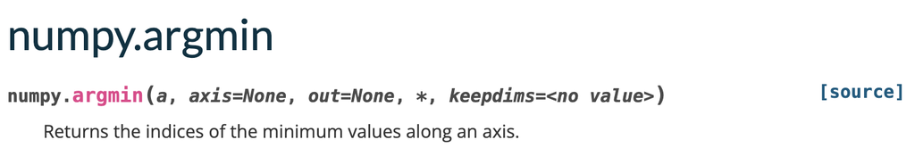

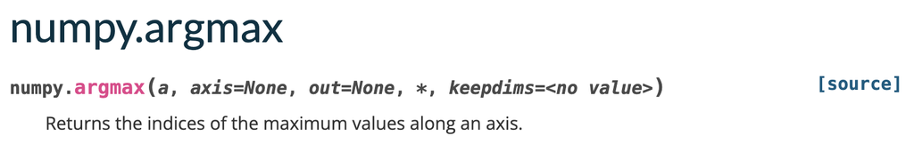

# Helper functions: sum

- Or the sum of its elements

```python
# Find the max of x.
np.sum(x)
```

```
85.0
```

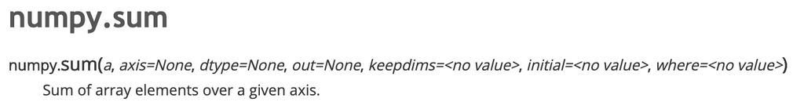

# Helper functions: mean and median

- We can check the mean and median of the elements present in the numeric array

```python
# Find the mean of x.
np.mean(x)
```

```
17.0
```

```python
# Find the median of x.
np.median(x)
```

```
17.0
```

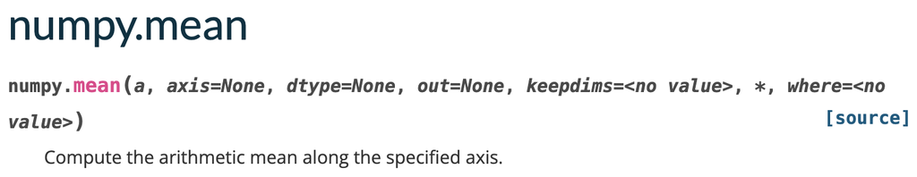

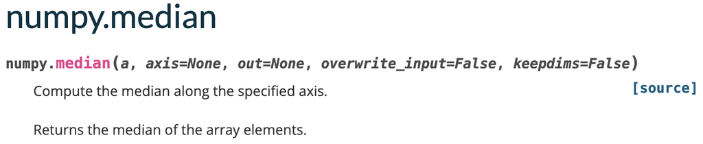

# Helper functions: digitize

- `digitize` is the function used to filter the elements of an array into respective bins
- Let’s define an array with the bins and filter the elements of array `x`

```python
# Filter array using digitize
bins = np.array([15, 17])
np.digitize(x,bins)
```

```
array([1, 1, 2, 2, 2])
```

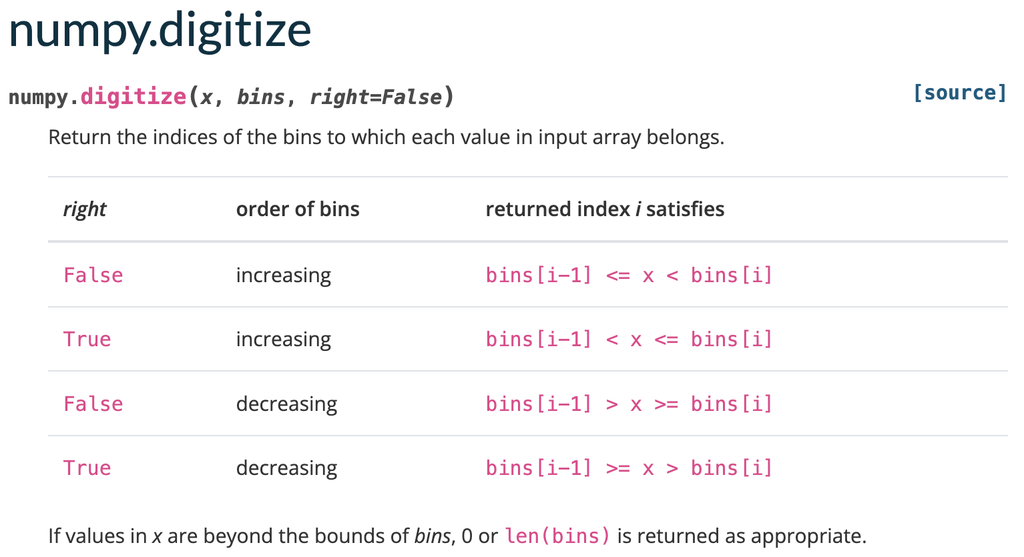

# Helper functions: expand and squeeze

- You can also choose to change the dimensions of the array using the `expand_dims` and `squeeze` functions

```python
# Expand dimensions of the array horizontally
np.expand_dims(x,axis=0)
```

```
array([[15., 16., 17., 18., 19.]])
```

```python
# Expand dimensions of the array vertically
np.expand_dims(x,axis=1)
```

```
array([[15.],
       [16.],
       [17.],
       [18.],
       [19.]])
```

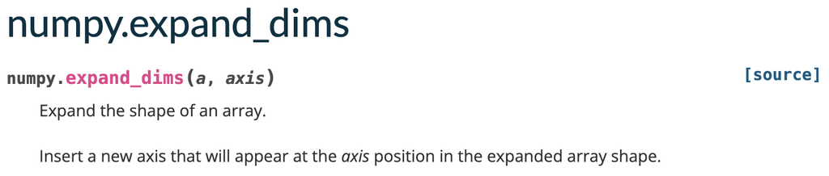

# Helper functions: expand and squeeze (cont’d)

```python
# Define an array in the format of lists
y = np.array([[10],[25],[28],[30]])
```

```python
# Reduce dimensions of the array
np.squeeze(y)
```

```
array([10, 25, 28, 30])
```

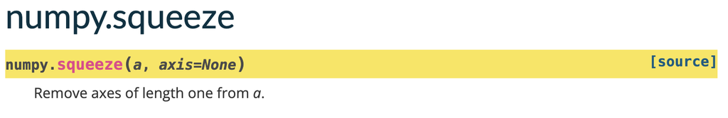

# Convert an array to a list

- We can convert an array to a normal `list` with the `list` function
- Let’s create the `evens` array and convert it to a list

```python
evens = np.arange(0, 23, 2)
print(list(evens))
```

```
[0, 2, 4, 6, 8, 10, 12, 14, 16, 18, 20, 22]
```

# Operations on arrays

- Numeric arrays of the same length can be added, subtracted, multiplied, or divided

```python
# Save two arrays as variables.
a = np.array([1,1,1,1])
b = np.array([2,2,2,2])

# Addition of arrays.
print(a + b)
```

```
[3 3 3 3]
```

```python
# Subtraction of arrays.
print(a - b)
```

```
[-1 -1 -1 -1]
```

```python
# Multiplication of arrays.
print(a * b)
```

```
[2 2 2 2]
```

```python
# Division of arrays.
print(a / b)
```

```
[0.5 0.5 0.5 0.5]
```

- In NumPy, these operations are defined element-wise
- In other words, each pair of corresponding elements in the two arrays is operated on, and the result is a new array containing each result

# Module completion checklist

| Objective | Complete |
| --- | --- |
| Perform operations on NumPy arrays | **✔** |
| Manipulating arrays using set operations |  |

# Set operations

- We can also perform set based operations like `intersect`, `union` and `difference` on numeric arrays
- Setting the `return_indices` parameter to `True` displays the indices of the common elements in both the arrays respectively

```python
# Retrieving common elements present in the arrays.
np.intersect1d(a, b, return_indices=True)
```

```
(array([], dtype=int64), array([], dtype=int64), array([], dtype=int64))
```

```python
# Retrieving elements present in both the arrays.
np.union1d(a, b)
```

```
array([1, 2])
```

```python
# Retrives the elements that are present only in the first array.
np.setdiff1d(a, b)
```

```
array([1])
```

# Stacking arrays

- Functions like `hstack` and `vstack` allow us to combine two arrays and stack them

```python
# Stacking arrays horizontally.
np.hstack((a,b))
```

```
array([1, 1, 1, 1, 2, 2, 2, 2])
```

```python
# Stacking arrays vertically.
np.vstack((a,b))
```

```
array([[1, 1, 1, 1],
       [2, 2, 2, 2]])
```

# Mathematical functions on lists

- We cannot perform operations on lists
- If we wanted an absolute value of a list of numbers, we can’t do this:

```python
abs([-2, -7, 1])
```

```
---------------------------------------------------------------------------
TypeError                                 Traceback (most recent call last)
<ipython-input-55-e2459d669344> in <module>()
----> 1 abs([-2, -7, 1])

TypeError: bad operand type for abs(): 'list'
```

- The `TypeError` tells us that `abs` is not set up to handle lists

# Mathematical functions on arrays

- Remember when we transformed a list into a NumPy array?
- Many functions in NumPy are vectorized functions, meaning they can handle a single input or an array of inputs
- When we use the same function `abs()` on an `np.` object, we see different results

```python
print(np.abs(-3))
```

```
3
```

```python
print(np.abs([-2, -7, 1]))
```

```
[2 7 1]
```

```python
nums = np.arange(20, 30, .5)
print(len(nums))
```

```
20
```

# User-defined functions on arrays

- We can also **write our own functions** to operate on arrays

```python
# Define a function to multiply every element in array with 3 and add 1
def some_calculation(arr):
    return 3*arr+1

print(some_calculation(nums))
```

```
[61.  62.5 64.  65.5 67.  68.5 70.  71.5 73.  74.5 76.  77.5 79.  80.5
 82.  83.5 85.  86.5 88.  89.5]
```

# Knowledge check

Link: https://forms.gle/DTzmnjH5yjUfhD9Q7

# Module completion checklist

| Objective | Complete |
| --- | --- |
| Perform operations on NumPy arrays | **✔** |
| Manipulating arrays using set operations | **✔** |

# Congratulations on completing this module!

You are now ready to try Tasks 3-6 in the Exercise for this topic